# Regresión Logistica con R - Vehiculos Familiares - Partir conjuntos de entrenamiento y pruebas con igual proporcion de vehiculos familiares y no familiares

Primero leemos los datos:

```r
#Cargamos el dataset
carros.dataset = read.csv("pricevshp.csv")

# Asignamos los nombres de las columnas
colnames(carros.dataset) <- c("Nombre","CaballosFuerza","Precio","Familiar")

carros.dataset
```

```
##                           Nombre CaballosFuerza Precio Familiar
## 1                      Merc 240D             62  11900        1
## 2                 Ford Festiva 4             63   6319        1
## 3                 Toyota Corolla             65  17872        1
## 4                       Fiat 128             66   3470        1
## 5                      Fiat X1-9             66   9640        1
## 6                 Subaru Justy 3             73   5866        1
## 7               Pontiac LeMans 4             74   7254        1
## 8                Toyota Tercel 4             78   6488        1
## 9               Mercury Tracer 4             82   8672        1
## 10               Ford Escort   4             90   7402        1
## 11               Nissan Sentra 4             90   7399        1
## 12               Subaru Loyale 4             90   9599        1
## 13                 Porsche 914-2             91  27500        0
## 14                 Honda Civic 4             92   6635        1
```

[output cut: 74 more lines]

Una representación gráfica de los datos, puede obtenerse mediante:

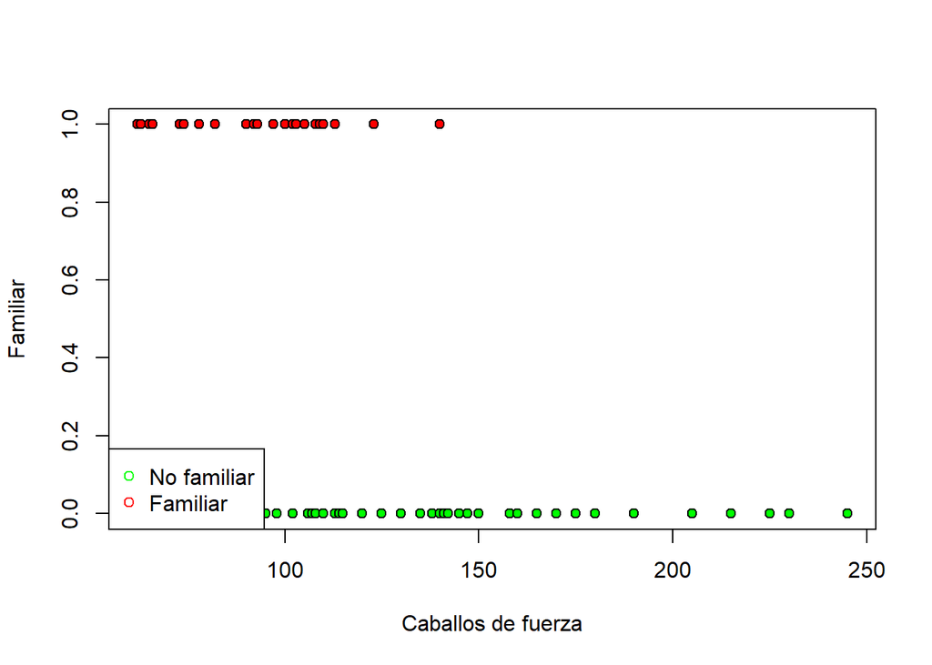

```r
colores <- NULL
colores[carros.dataset$Familiar==0] <- 'green' #No familiar
colores[carros.dataset$Familiar==1] <- 'red' #Familiar
plot(carros.dataset$CaballosFuerza, carros.dataset$Familiar, pch = 21, bg = colores, xlab = 'Caballos de fuerza', ylab = 'Familiar')
legend('bottomleft', c('No familiar', 'Familiar'), pch = 21, col = c('green', 'red'))
```

Hemos usado los argumentos pch y bg para mejorar la apariencia del gráfico. También hemos usado el comando legend para incluir una leyenda explicativa.

Parece razonable, a la vista de los datos, pensar que los caballos de fuerza puede influir en la probabilidad de que un carro sea familiar o no. En esta práctica, vamos a ajustar un modelo de regresión logística para estudiar la posible relación. Para ajustar el modelo se usa el comando glm (para modelos lineales generalizados) indicando que la respuesta es binomial mediante el argumento family:

## Partimos los datos en conjunto de entrenamiento y pruebas

```r
set.seed(1234) # semilla

#Separamos los vehiculos familiares y no familiares
vehiculos.familiares = carros.dataset[which(carros.dataset$Familiar==1),]
vehiculos.nofamiliares = carros.dataset[which(carros.dataset$Familiar==0),]

muestra.cantidad.familiar <- floor(0.7 * nrow(vehiculos.familiares))
muestra.cantidad.nofamiliar <- floor(0.7 * nrow(vehiculos.nofamiliares))

entrenamiento.familiar.index <- sample(seq_len(nrow(vehiculos.familiares)), size = muestra.cantidad.familiar) #23
entrenamiento.nofamiliar.index <- sample(seq_len(nrow(vehiculos.nofamiliares)), size = muestra.cantidad.nofamiliar) #38

conjunto_entrenamiento_familiar <- vehiculos.familiares[entrenamiento.familiar.index, ]
conjunto_prueba_familiar <- vehiculos.familiares[- entrenamiento.familiar.index, ]

conjunto_entrenamiento_nofamiliar <- vehiculos.nofamiliares[entrenamiento.nofamiliar.index, ]
conjunto_prueba_nofamiliar <- vehiculos.nofamiliares[- entrenamiento.nofamiliar.index, ]

#Unimos los dataset
conjunto_entrenamiento = rbind(conjunto_entrenamiento_familiar, conjunto_entrenamiento_nofamiliar)
conjunto_prueba = rbind(conjunto_prueba_familiar, conjunto_prueba_nofamiliar)
```

```r
#Veamos la proporcion de vehiculos no familiares en cada dataset de entrenamiento y prueba
tablaEntrenamiento <- table(conjunto_entrenamiento$Familiar)
prop.table(tablaEntrenamiento)
```

```
##
##         0         1
## 0.6229508 0.3770492
```

```r
tablaPrueba <- table(conjunto_prueba$Familiar)
prop.table(tablaPrueba)
```

```
##
##         0         1
## 0.6296296 0.3703704
```

Podemos observar que las proporciones en ambos conjuntos son muy parecidas. No son exactas dado a que los tamaños de los dataset son discretos.

Tambien podemos hacerlo de forma automatica, usando la libreria “splitstackshape” y la funcion stratified

```r
#library(splitstackshape)

#set.seed(1234) # semilla
#aux <- stratified(carros.dataset, c("Familiar"), size = .3, bothSets = TRUE, keep.rownames=TRUE)
#conjunto_prueba = aux$SAMP1
#conjunto_entrenamiento = aux$SAMP2
```

```r
#Veamos la proporcion de vehiculos no familiares en cada dataset de entrenamiento y prueba
#tablaEntrenamiento <- table(conjunto_entrenamiento$Familiar)
#prop.table(tablaEntrenamiento)

#tablaPrueba <- table(conjunto_prueba$Familiar)
#prop.table(tablaPrueba)
```

```r
reg <- glm(Familiar ~ CaballosFuerza, data = conjunto_entrenamiento, family=binomial)
summary(reg)
```

```
##
## Call:
## glm(formula = Familiar ~ CaballosFuerza, family = binomial, data = conjunto_entrenamiento)
##
## Deviance Residuals:
##      Min        1Q    Median        3Q       Max
## -1.71058  -0.32223  -0.07005   0.52726   2.26803
##
## Coefficients:
##                Estimate Std. Error z value Pr(>|z|)
## (Intercept)     9.81485    2.84679   3.448 0.000565 ***
## CaballosFuerza -0.08791    0.02535  -3.468 0.000524 ***
## ---
## Signif. codes:  0 '***' 0.001 '**' 0.01 '*' 0.05 '.' 0.1 ' ' 1
##
## (Dispersion parameter for binomial family taken to be 1)
##
##     Null deviance: 80.837  on 60  degrees of freedom
## Residual deviance: 38.949  on 59  degrees of freedom
## AIC: 42.949
##
## Number of Fisher Scoring iterations: 7
```

En el modelo de regresión logística la raíz de las desviaciones representa el papel de los residuos:

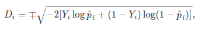

Para representar gráficamente la función logística estimada, calculamos las probabilidades estimadas de ser un carro familiar o no (usando el comando predict) para un vector adecuado de nuevos valores de caballos de fuerza (entre 60 hp y 250 hp):

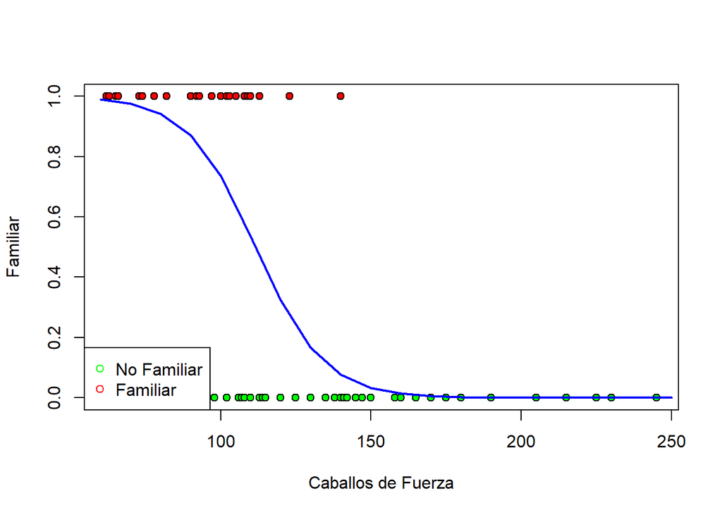

```r
datos <- data.frame(CaballosFuerza = seq(60, 250, 10))
probabilidades <- predict(reg, datos, type = 'response')  # por defecto calcularía log p_i/(1-p_i), para calcular p_i usamos el argumento type
plot(carros.dataset$CaballosFuerza, carros.dataset$Familiar, pch = 21, bg = colores, xlab = 'Caballos de Fuerza', ylab = 'Familiar')
legend('bottomleft', c('No Familiar', 'Familiar'), pch = 21, col = c('green', 'red'))
lines(datos$CaballosFuerza, probabilidades, col = 'blue', lwd = 2)
```

## Predicción (usando modelo logistico)

Usamos el conjunto de pruebas y probamos el modelo. Se deben redondear las predicciones resultantes a el entero más cercano para poder compararlas con la clase verdadera.

```r
prediccion_logistica <-predict(reg, conjunto_prueba, type="response")
prediccion_clase <- as.factor(ifelse(prediccion_logistica >= 0.5, 1, 0)) # Cambiamos valores a 1s y 0s
prediccion_clase
```

```
##  8  9 10 11 16 26 31 33 34 55 13 17 27 28 30 38 42 47 51 58 59 60 62 63 72
##  1  1  1  1  1  1  1  1  1  0  1  1  1  1  1  1  1  0  0  0  0  0  0  0  0
## 79 85
##  0  0
## Levels: 0 1
```

## Matriz de confusión para las predicciones

Una matriz de confusión es una herramienta que permite la visualización del desempeño de un algoritmo que se emplea en aprendizaje supervisado. Cada columna de la matriz representa el número de predicciones de cada clase, mientras que cada fila representa a las instancias en la clase real.

```r
library("caret")
confusionMatrix(as.factor(conjunto_prueba$Familiar), prediccion_clase)
```

```
## Confusion Matrix and Statistics
##
##           Reference
## Prediction  0  1
##          0 10  7
##          1  1  9
##
##                Accuracy : 0.7037
##                  95% CI : (0.4982, 0.8625)
##     No Information Rate : 0.5926
##     P-Value [Acc > NIR] : 0.1639
##
##                   Kappa : 0.4346
##  Mcnemar's Test P-Value : 0.0771
##
##             Sensitivity : 0.9091
##             Specificity : 0.5625
##          Pos Pred Value : 0.5882
##          Neg Pred Value : 0.9000
##              Prevalence : 0.4074
##          Detection Rate : 0.3704
##    Detection Prevalence : 0.6296
##       Balanced Accuracy : 0.7358
##
##        'Positive' Class : 0
##
```

Podemos observar que se obtuvo una exactitud del 70% con el conjunto de pruebas.